# Scikit-learn basics

`Scikit-learn` is one of the science kits for `SciPy` stack. Scikit has a collection of prediction and learning algorithms, grouped into

- classification
- clustering
- regression
- dimensionality reduction

Each algorithm follows a typical pattern with a `fit`, `predict` method. In addition you get a set of utility methods that help with splitting datasets into train-test sets and for validating the outputs.

```python
import pandas as pd
import matplotlib.pyplot as plt
%matplotlib inline
import seaborn as sns
```

## Predicting housing prices using multiple linear regression

### Exploratory data anslysis (EDA)

```python
import os
os.getcwd()
```

```
'/Users/atma6951/Documents/code/pychakras/pychakras/ml'
```

```python
usa_house = pd.read_csv('../udemy_ml_bootcamp/Machine Learning Sections/Linear-Regression/USA_housing.csv')
usa_house.head(5)
```

|  | Avg. Area Income | Avg. Area House Age | Avg. Area Number of Rooms | Avg. Area Number of Bedrooms | Area Population | Price | Address |
| --- | --- | --- | --- | --- | --- | --- | --- |
| 0 | 79545.458574 | 5.682861 | 7.009188 | 4.09 | 23086.800503 | 1.059034e+06 | 208 Michael Ferry Apt. 674\nLaurabury, NE 3701... |
| 1 | 79248.642455 | 6.002900 | 6.730821 | 3.09 | 40173.072174 | 1.505891e+06 | 188 Johnson Views Suite 079\nLake Kathleen, CA... |
| 2 | 61287.067179 | 5.865890 | 8.512727 | 5.13 | 36882.159400 | 1.058988e+06 | 9127 Elizabeth Stravenue\nDanieltown, WI 06482... |
| 3 | 63345.240046 | 7.188236 | 5.586729 | 3.26 | 34310.242831 | 1.260617e+06 | USS Barnett\nFPO AP 44820 |
| 4 | 59982.197226 | 5.040555 | 7.839388 | 4.23 | 26354.109472 | 6.309435e+05 | USNS Raymond\nFPO AE 09386 |

```python
usa_house.info()
```

```
<class 'pandas.core.frame.DataFrame'>
RangeIndex: 5000 entries, 0 to 4999
Data columns (total 7 columns):
Avg. Area Income                5000 non-null float64
Avg. Area House Age             5000 non-null float64
Avg. Area Number of Rooms       5000 non-null float64
Avg. Area Number of Bedrooms    5000 non-null float64
Area Population                 5000 non-null float64
Price                           5000 non-null float64
Address                         5000 non-null object
dtypes: float64(6), object(1)
memory usage: 273.5+ KB
```

```python
usa_house.describe()
```

|  | Avg. Area Income | Avg. Area House Age | Avg. Area Number of Rooms | Avg. Area Number of Bedrooms | Area Population | Price |
| --- | --- | --- | --- | --- | --- | --- |
| count | 5000.000000 | 5000.000000 | 5000.000000 | 5000.000000 | 5000.000000 | 5.000000e+03 |
| mean | 68583.108984 | 5.977222 | 6.987792 | 3.981330 | 36163.516039 | 1.232073e+06 |
| std | 10657.991214 | 0.991456 | 1.005833 | 1.234137 | 9925.650114 | 3.531176e+05 |
| min | 17796.631190 | 2.644304 | 3.236194 | 2.000000 | 172.610686 | 1.593866e+04 |
| 25% | 61480.562388 | 5.322283 | 6.299250 | 3.140000 | 29403.928702 | 9.975771e+05 |
| 50% | 68804.286404 | 5.970429 | 7.002902 | 4.050000 | 36199.406689 | 1.232669e+06 |
| 75% | 75783.338666 | 6.650808 | 7.665871 | 4.490000 | 42861.290769 | 1.471210e+06 |
| max | 107701.748378 | 9.519088 | 10.759588 | 6.500000 | 69621.713378 | 2.469066e+06 |

Find the correlation between each of the numerical columns to the house price

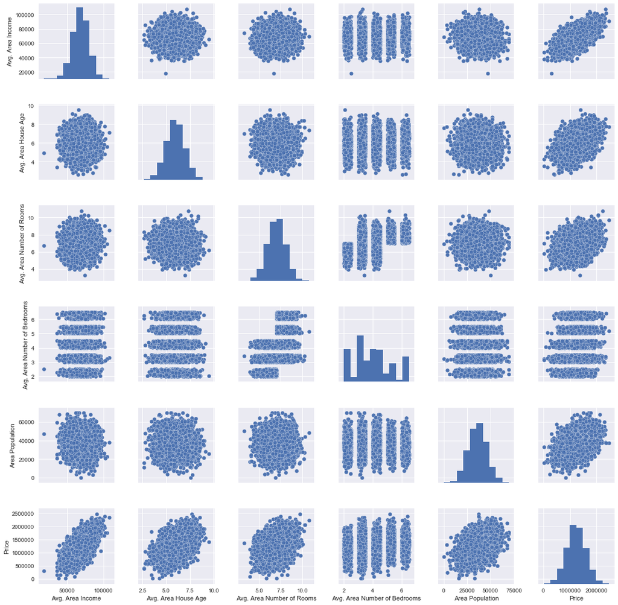

```python
sns.pairplot(usa_house)
```

From this chart, we now,

- distribution of house price is normal (last chart)
- some scatters show a higher correlation, while some other show no correlation.

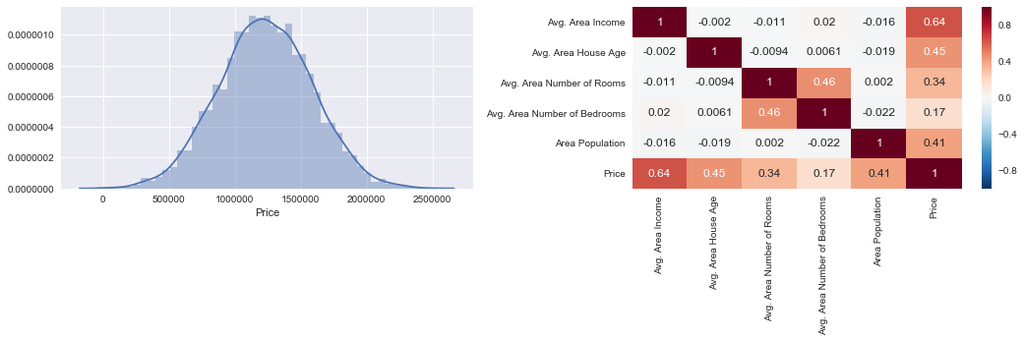

```python
fig, axs = plt.subplots(1,2, figsize=[15,5])
sns.distplot(usa_house['Price'], ax=axs[0])
sns.heatmap(usa_house.corr(), ax=axs[1], annot=True)
fig.tight_layout()
```

## Data cleaning

Throw out the text column and split the data into predictor and predicted variables

```python
usa_house.columns
```

```
Index(['Avg. Area Income', 'Avg. Area House Age', 'Avg. Area Number of Rooms',
       'Avg. Area Number of Bedrooms', 'Area Population', 'Price', 'Address'],
      dtype='object')
```

```python
X = usa_house[['Avg. Area Income', 'Avg. Area House Age', 'Avg. Area Number of Rooms',
       'Avg. Area Number of Bedrooms', 'Area Population']]

y = usa_house[['Price']]
```

### Train test split

```python
from sklearn.model_selection import train_test_split
X_train, X_test, y_train, y_test = train_test_split(X, y, test_size=0.33)
```

```python
len(X_train)
```

```
3350
```

```python
len(X_test)
```

```
1650
```

```python
X_test.head()
```

|  | Avg. Area Income | Avg. Area House Age | Avg. Area Number of Rooms | Avg. Area Number of Bedrooms | Area Population |
| --- | --- | --- | --- | --- | --- |
| 1605 | 71368.044019 | 6.014409 | 7.025588 | 6.21 | 35376.990733 |
| 601 | 96807.436912 | 6.182168 | 7.301724 | 5.07 | 29269.137336 |
| 1140 | 79477.869514 | 5.833289 | 6.933969 | 3.17 | 30411.184394 |
| 571 | 88794.599629 | 6.323866 | 7.060330 | 6.11 | 37994.973849 |
| 1459 | 35963.330809 | 3.438547 | 8.264122 | 3.28 | 24435.777302 |

## Multiple regression

We use a number of numerical columns to regress the house price. Each column's influence will vary, just like in real life, the number of bedrooms might not influence as much as population density. We can determine the influence from the correlation shown in the heatmap above

```python
from sklearn.linear_model import LinearRegression
lm = LinearRegression()
```

### Fit

```python
lm.fit(X_train, y_train) #no need to capture the return. All is stored in lm
```

```
LinearRegression(copy_X=True, fit_intercept=True, n_jobs=1, normalize=False)
```

```python
#print the linear model built
print("y = " + str(lm.coef_[0]) + "*X" + " + " + str(lm.intercept_[0]))
```

```
y = [  2.15421903e+01   1.63929020e+05   1.19503896e+05   8.85037978e+02
   1.51071242e+01]*X + -2608058.46619
```

Create a table showing the coefficient (influence) of each of the columns

```python
cdf = pd.DataFrame(lm.coef_[0], index=X_train.columns, columns=['coefficients'])
cdf
```

|  | coefficients |
| --- | --- |
| Avg. Area Income | 21.542190 |
| Avg. Area House Age | 163929.020281 |
| Avg. Area Number of Rooms | 119503.895634 |
| Avg. Area Number of Bedrooms | 885.037978 |
| Area Population | 15.107124 |

### Predict

```python
y_predicted = lm.predict(X_test)
len(y_predicted)
```

```
1650
```

### Accuracy assessment / Model validation

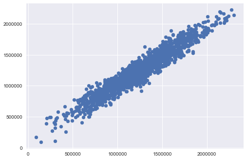

```python
plt.scatter(y_test, y_predicted) #actual vs predicted
```

#### Distribution of residuals

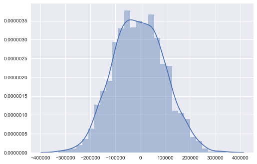

```python
sns.distplot((y_test - y_predicted))
```

#### Quantifying errors

```python
from sklearn import metrics
metrics.mean_absolute_error(y_test, y_predicted)
```

```
83335.710914804557
```

RMSE

```python
import numpy
numpy.sqrt(metrics.mean_squared_error(y_test, y_predicted))
```

```
102708.76131013762
```

### Combine the predicted values with input

```python
X_test['predicted_price'] = y_predicted
```

```python
X_test.head()
```

|  | Avg. Area Income | Avg. Area House Age | Avg. Area Number of Rooms | Avg. Area Number of Bedrooms | Area Population | predicted_price |
| --- | --- | --- | --- | --- | --- | --- |
| 1605 | 71368.044019 | 6.014409 | 7.025588 | 6.21 | 35376.990733 | 1.294827e+06 |
| 601 | 96807.436912 | 6.182168 | 7.301724 | 5.07 | 29269.137336 | 1.810067e+06 |
| 1140 | 79477.869514 | 5.833289 | 6.933969 | 3.17 | 30411.184394 | 1.351182e+06 |
| 571 | 88794.599629 | 6.323866 | 7.060330 | 6.11 | 37994.973849 | 1.764576e+06 |
| 1459 | 35963.330809 | 3.438547 | 8.264122 | 3.28 | 24435.777302 | 9.000000e+04 |